# Exploration 1 : La précarité énergétique des quartiers de Rouen

Révisions de statistique bivariée

Author

Claude Grasland

Published

March 9, 2026

```r
library(knitr)
library(dplyr)

library(questionr)
library(FactoMineR)

library(sf)
library(mapsf)
library(ggplot2)
```

Dans cette première exploration on va commencer en prendre en main les données en se donnant comme objectif d’étudier les variations de précarité énergétique entre les quartiers de la commune de Rouen. On se limitera à l’utilisation d’outils statistiques - apparemment - simples de statistique bivariée que l’on complexifiera progressivement.

## 1. Données

### Données géométriques

On extrait du fond de carte des 42 IRIS la commune de Rouen et on crée un fonds de carte regroupant ceux-ci en 10 quartiers.

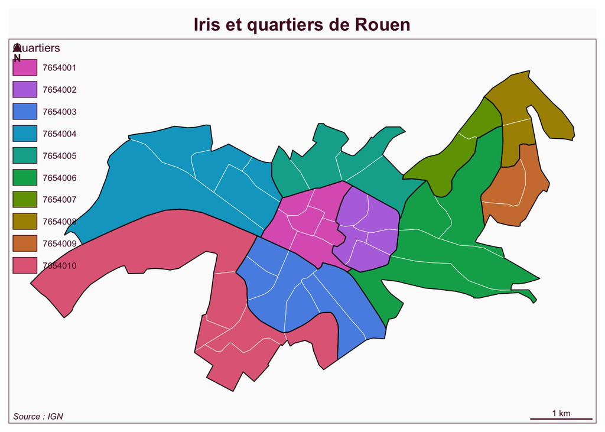

```r
map_iris <- readRDS("data/mapiris.RDS") %>% filter(substr(iris_code,1,5)=="76540")
map_quart <- map_iris %>% group_by(quart_code, quart_name) %>%
                         summarise()
map_com <- map_iris %>% summarise()


mf_map(map_iris, type="typo",var="quart_code", border="white",lwd=0.5, leg_title = "Quartiers")
mf_map(map_quart, type = "base", col=NA, add=T, border="black",lwd=1)
mf_layout("Iris et quartiers de Rouen", frame = T, credits = "Source : IGN")
```

### Données statistiques

On extrait du fichier DPE les diagnistics relatifs à la commune de Rouen et on sélectionne un nombre volontairement limité d’indicateurs.

```r
map_dpe<-readRDS("data/dpe.RDS") %>%
           filter(com_code == "76540",
                  substr(quart_code,1,5) == "76540") %>%
           select(quart_code,
                  quart_name,
                  dpe,
                  sup,
                  con_tot,
                  con_m2,
                  dat,
                  typ) %>%
          mutate(quart_code = as.character(quart_code),
                 quart_name = as.character(quart_name))
don<-st_drop_geometry(map_dpe) %>% filter(is.na(dpe)==F,
                                          is.na(con_m2)==F)

kable(head(don), caption= "Extrait du fichier DPE")
```

Extrait du fichier DPE

| quart_code | quart_name | dpe | sup | con_tot | con_m2 | dat | typ |
| --- | --- | --- | --- | --- | --- | --- | --- |
| 7654001 | Centre Rive Droite Ouest | D | 56.7 | 13449.7 | 237.2 | 1900 | appartement |
| 7654006 | Quartiers Est | F | 90.6 | 29722.1 | 328.0 | 1948 | appartement |
| 7654001 | Centre Rive Droite Ouest | D | 70.0 | 12936.9 | 192.0 | 1949 | maison |
| 7654003 | Centre Rive Gauche | G | 19.7 | 15175.8 | 769.1 | 1949 | appartement |
| 7654001 | Centre Rive Droite Ouest | D | 62.1 | 15101.9 | 243.0 | 1947 | appartement |
| 7654002 | Centre Rive Droite Est | E | 35.7 | 4503.5 | 289.0 | 1948 | appartement |

### Superposition

On superpose les deux sources de données en utilisant les localisations du fichier dpe :

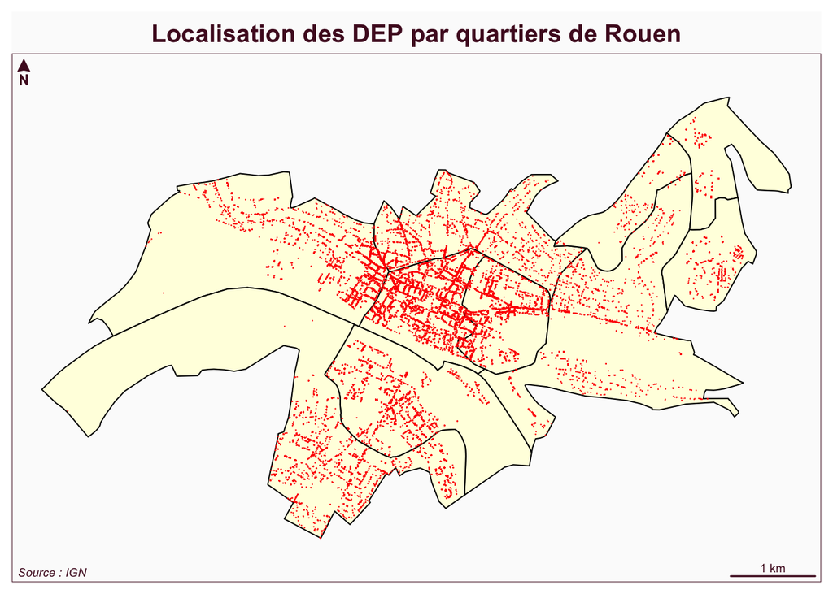

```r
mf_map(map_quart, type = "base", col="lightyellow", border="black",lwd=1)
mf_map(map_dpe, type="base", col="red",pch=20, cex=0.1, add=T)
mf_layout("Localisation des DEP par quartiers de Rouen", frame = T, credits = "Source : IGN")
```

## 2. Quelle mesure de précarité ?

Quelle est la variable que nous souhaitons analyser ? Les passoires énergétiques sont en principe définies par l’appartenance aux catégories énergétiques F et G.

### Etiquette énergétique en 7 classes

Quelle est la distribution générale des étiquettes énergétiques ? Réalisons un tableau et un graphique.

```r
#Tableau
tab <- freq(don$dpe,cum = T,valid = F)
kable(tab, caption = "Etiquettes énergétiques des logements")
```

Etiquettes énergétiques des logements

|  | n | % | %cum |
| --- | --- | --- | --- |
| A | 144 | 0.3 | 0.3 |
| B | 1194 | 2.2 | 2.5 |
| C | 15512 | 29.1 | 31.6 |
| D | 17211 | 32.3 | 64.0 |
| E | 11988 | 22.5 | 86.5 |
| F | 4209 | 7.9 | 94.4 |
| G | 2987 | 5.6 | 100.0 |

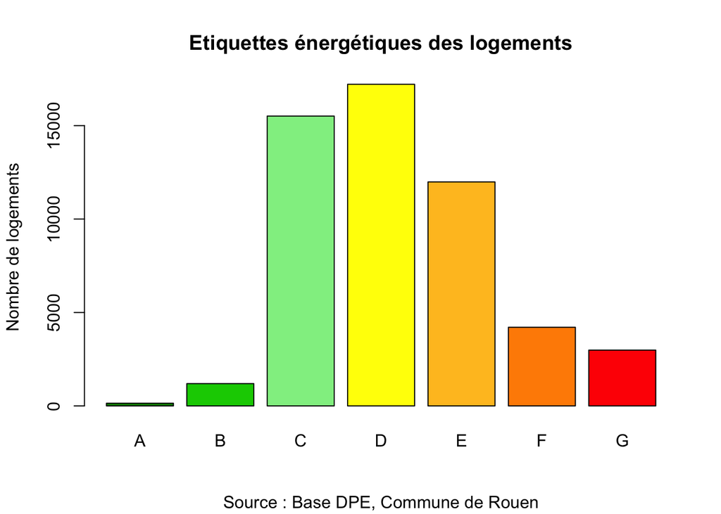

```r
# Graphique
mypal7<-c("green4","green3","lightgreen","yellow","goldenrod1","darkorange","red")
plot(don$dpe, col=mypal7,
        main = "Etiquettes énergétiques des logements",
        sub =  "Source : Base DPE, Commune de Rouen",
        ylab = "Nombre de logements")
```

### Etiquette et consommation d’énergie primaire par m2

Même si la correspondance n’est pas parfaite, il existe un lien étroit entre la consommation d’énergie primaire par m2 de logement habitable (en log) et l’étiquette DPE attribuée par l’ADEME.

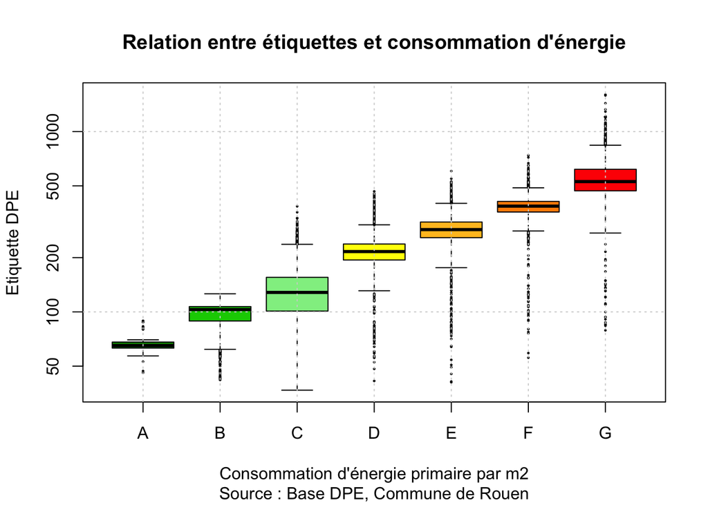

```r
# Graphique R-Base
mypal7<-c("green4","green3","lightgreen","yellow","goldenrod1","darkorange","red")
boxplot(don$con_m2~don$dpe,
        col=mypal7,
        cex=0.2,
        log ="y",
        xlab="Consommation d'énergie primaire par m2",
        ylab = "Etiquette DPE",
        main="Relation entre étiquettes et consommation d'énergie",
        sub = "Source : Base DPE, Commune de Rouen")
grid(lwd=1)
```

```r
#Graphique ggplot2
mypal7<-c("green4","green3","lightgreen","yellow","goldenrod1","darkorange","red")
ggplot(don) + aes(x=dpe,y=con_m2)+
              geom_violin(aes(fill=dpe)) +
              scale_y_log10("Consommation d'énergie primaire par m2") +
              scale_x_discrete("Etiquette DPE")+
              scale_fill_manual(values=mypal7) +
              theme_light() +
              ggtitle(label = "Relation entre étiquettes et consommation d'énergie",
                      subtitle = "Source : Base DPE, Commune de Rouen"
                        )
```

[output not shown]

Ceci suggère que l’analyse pourrait dans certains cas porter sur cette **variable quantitative continue** plutôt que sur la variable **qualitative ordinale** qu’est l’étiquette. Mais en utilisant de préférence une échelle logarithmique.

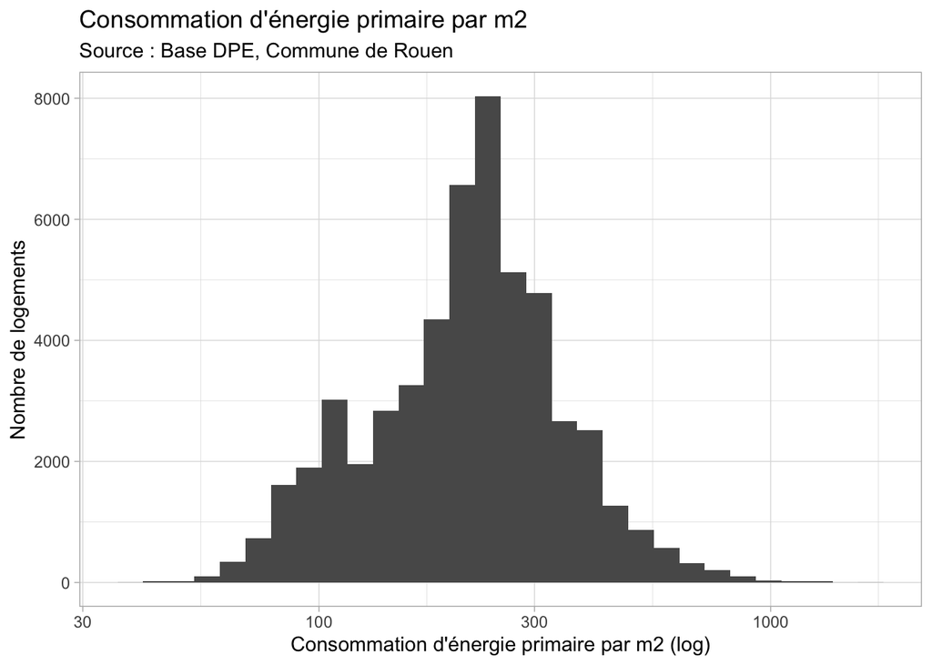

```r
ggplot(don, aes(x=con_m2)) +
      geom_histogram()+
      scale_x_log10("Consommation d'énergie primaire par m2 (log)") +
      scale_y_continuous("Nombre de logements") +
      theme_light() +
      ggtitle(label = "Consommation d'énergie primaire par m2",
                      subtitle = "Source : Base DPE, Commune de Rouen"
                        )
```

### Seuil énergétique des passoires

On peut assez facilement déduire empiriquement le seuil d’apparition des passoires énergétiques à l’aide d’un **modèle Logit** :

```r
don$dpe2 <- don$dpe %in% c("F","G")
mod1 <- glm(formula = dpe2~con_m2, family = "binomial", data=don)
summary(mod1)
```

```
Call:
glm(formula = dpe2 ~ con_m2, family = "binomial", data = don)

Coefficients:
              Estimate Std. Error z value Pr(>|z|)
(Intercept) -1.745e+01  2.346e-01  -74.39   <2e-16 ***
con_m2       4.891e-02  6.818e-04   71.74   <2e-16 ***
---
Signif. codes:  0 '***' 0.001 '**' 0.01 '*' 0.05 '.' 0.1 ' ' 1

(Dispersion parameter for binomial family taken to be 1)

    Null deviance: 42176.3  on 53244  degrees of freedom
Residual deviance:  9537.9  on 53243  degrees of freedom
AIC: 9541.9

Number of Fisher Scoring iterations: 9
```

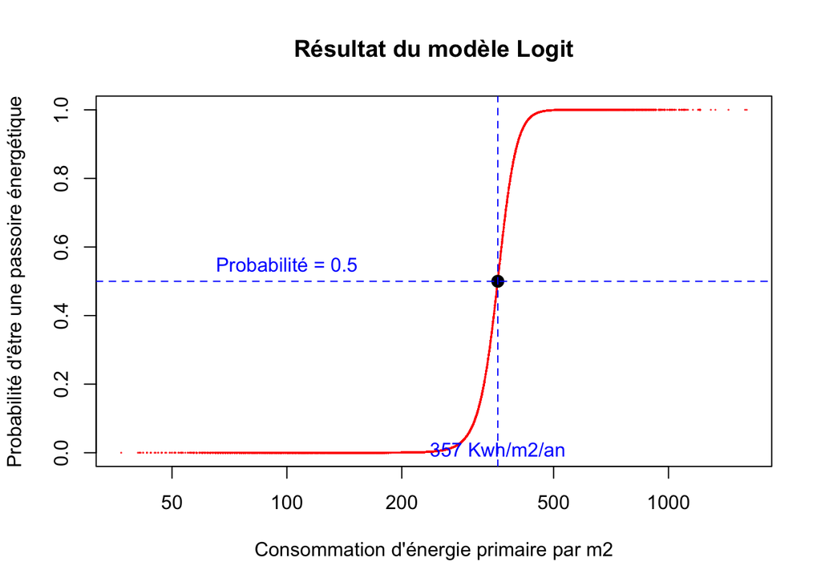

```r
plot(mod1$data$con_m2,
     mod1$fitted.values,
     cex=0.1,
     pch=20,
     col="red",
     log="x",
     main = "Résultat du modèle Logit",
     xlab = "Consommation d'énergie primaire par m2",
     ylab = "Probabilité d'être une passoire énergétique",
     subtitle = "Source : Base DPE, Commune de Rouen")
points(357, 0.5, pch=20, cex=2)
text(100, 0.55, "Probabilité = 0.5", col="blue")
text(357, 0.01, "357 Kwh/m2/an", col="blue")
abline(h=0.5, lty=2, col = "blue")
abline(v=357, lty=2, col= "blue")
```

La valeur seuil obtenue est de **357 Kwh/m2**, ce qui est légèrement supérieur à la valeur de référence donnée par l’ADEME qui est de **330 Kwh/m2/an** pour le passage de la catégorie E à la catégorie F. On peut vérifier que l’approximation est nénamoins très proche de la réalité en comparant les passoires énergétiques déclarées par l’ADEME et l’estimation faite à partir du seuil observé grâce au modèle Logit :

```r
obs <-don$dpe2
est <-don$con_m2 > 357
conf<-table(obs,est)
tabres <- addmargins(conf)
tabres
```

```
       est
obs     FALSE  TRUE   Sum
  FALSE 45441   608 46049
  TRUE   1087  6109  7196
  Sum   46528  6717 53245
```

## 3. Précarité par quartier

### Pourcentage de passoires

Si on part de la variable booléenne, on obtient facilement un pourcentage de passoires énergétiques par quartier :

```r
tab1 <- don %>% group_by(quart_code, quart_name) %>%
                summarise(tot = n(),
                          pas = sum(dpe2)) %>%
                mutate(pct = 100*pas/tot) %>%
                arrange(pct)
kable(tab1,
      digits = c(0,0,0,0,2),
      col.names = c("Code","Nom","Total", "N", "%"),
      caption = "Nombre et proportion de passoires énergétiques par quartier")
```

Nombre et proportion de passoires énergétiques par quartier

| Code | Nom | Total | N | % |
| --- | --- | --- | --- | --- |
| 7654008 | Chatelet Lombardie | 2079 | 0 | 0.00 |
| 7654009 | Grand Mare | 2622 | 40 | 1.53 |
| 7654007 | Sapins | 2439 | 175 | 7.18 |
| 7654010 | Saint-Clément-Jardin des Plantes | 6676 | 506 | 7.58 |
| 7654003 | Centre Rive Gauche | 7352 | 571 | 7.77 |
| 7654006 | Quartiers Est | 3184 | 399 | 12.53 |
| 7654002 | Centre Rive Droite Est | 8133 | 1020 | 12.54 |
| 7654004 | Quartiers Ouest | 7145 | 1020 | 14.28 |
| 7654001 | Centre Rive Droite Ouest | 9664 | 2350 | 24.32 |
| 7654005 | Coteaux Nord | 3951 | 1115 | 28.22 |

On peut cartogaphier le résultat pour visualiser la distribution dans la commune :

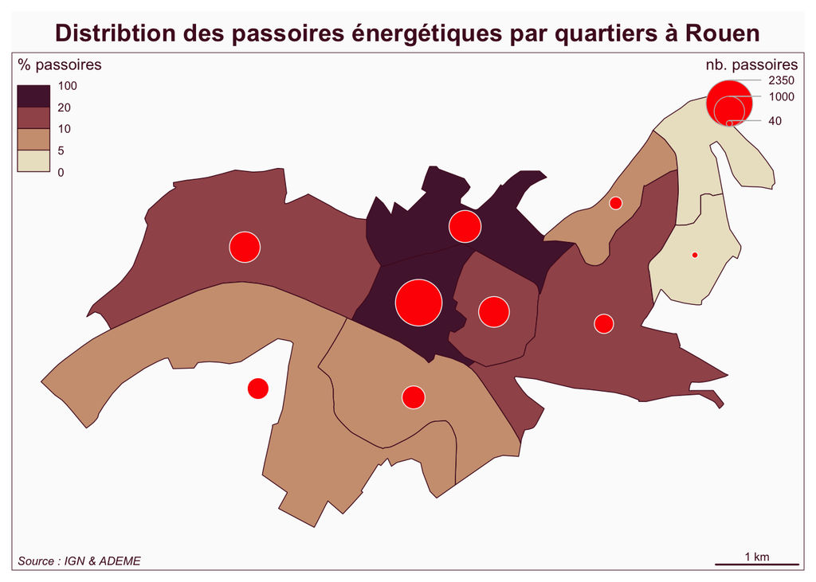

```r
map2 <- map_quart %>% left_join(tab1)

mf_map(map2, type="choro",var="pct",
       breaks=c(0,5,10,20,100),
       leg_title = "% passoires",
       leg_val_rnd = 0,
       leg_pos = "topleft")
mf_map(map2, type="prop", var="pas",
       leg_title = "nb. passoires",
       leg_pos = "topright",
       inches=0.2,
       col="red")
mf_layout("Distribtion des passoires énergétiques par quartiers à Rouen",
          arrow = F,
          frame = T,
          credits = "Source : IGN & ADEME")
```

### Consommation moyenne d’énergie primaire par m2

Supposons maintenant que l’on veuille calculer pour chaque quartier la valeur moyenne de conosmmation d’énergie par m2.

```r
tab1 <- don %>% group_by(quart_code, quart_name) %>%
                filter(is.na(con_tot)==F,
                       is.na(sup) ==F) %>%
                summarise(con_tot = sum(con_tot),
                          sup = sum(sup)) %>%
                mutate(con_m2 = con_tot/sup) %>%
                arrange(con_m2)
kable(tab1,
      digits = c(0,0,0,0,2),
      col.names = c("Code","Nom","Consommation totale", "Surface", "Consommation / m2"),
      caption = "Consommation moyenne d'énergie primaire par m2 selon les quartiers")
```

Consommation moyenne d’énergie primaire par m2 selon les quartiers

| Code | Nom | Consommation totale | Surface | Consommation / m2 |
| --- | --- | --- | --- | --- |
| 7654008 | Chatelet Lombardie | 20502860 | 133059 | 154.09 |
| 7654010 | Saint-Clément-Jardin des Plantes | 73275344 | 407292 | 179.91 |
| 7654009 | Grand Mare | 34340742 | 188199 | 182.47 |
| 7654003 | Centre Rive Gauche | 75064211 | 393148 | 190.93 |
| 7654006 | Quartiers Est | 36867568 | 171576 | 214.88 |
| 7654004 | Quartiers Ouest | 76970066 | 347701 | 221.37 |
| 7654002 | Centre Rive Droite Est | 83604011 | 373750 | 223.69 |
| 7654007 | Sapins | 29975978 | 133836 | 223.98 |
| 7654005 | Coteaux Nord | 60592161 | 221901 | 273.06 |
| 7654001 | Centre Rive Droite Ouest | 122574781 | 444471 | 275.78 |

On peut cartogaphier le résultat pour visualiser la distribution dans la commune :

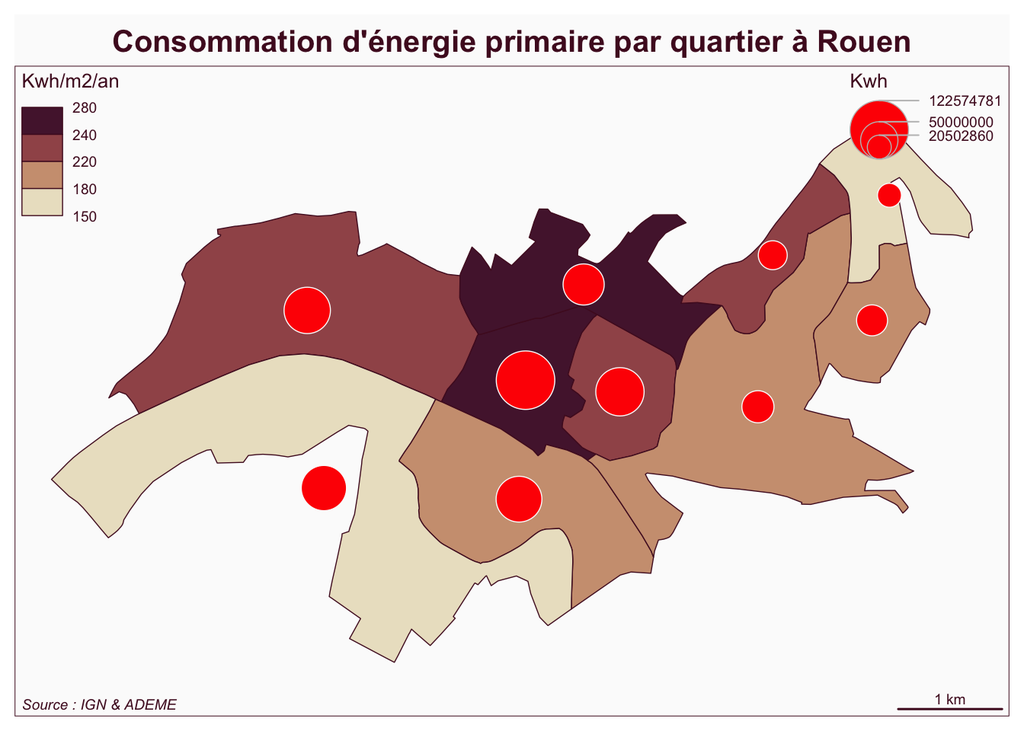

```r
map2 <- map_quart %>% left_join(tab1)

mf_map(map2, type="choro",var="con_m2",
      breaks=c(150,180,220,240,280),
       leg_title = "Kwh/m2/an",
       leg_val_rnd = 0,
       leg_pos = "topleft")
mf_map(map2, type="prop", var="con_tot",
       leg_title = "Kwh",
       leg_pos = "topright",
       inches=0.2,
       col="red")
mf_layout("Consommation d'énergie primaire par quartier à Rouen",
          arrow = F,
          frame = T,
          credits = "Source : IGN & ADEME")
```

## 4. Classification des profils d’étiquette

Une solution différente consiste à partir du tableau de contingence croisant les quartiers et les étiquettes pour en analyser la structure interne et en déduire une classification des quartiers.

### Tableau de contingence

On construite le tableau de contingence qui répartit les logements en fonction de leur étiquette et deleur quartier :

```r
tab <- table(don$quart_name,don$dpe)
tabcont <-as.matrix(tab)
kable(addmargins(tabcont), caption = "Tableau de contingence croisant quartiers ét étiquettes DPE")
```

Tableau de contingence croisant quartiers ét étiquettes DPE

|  | A | B | C | D | E | F | G | Sum |
| --- | --- | --- | --- | --- | --- | --- | --- | --- |
| Centre Rive Droite Est | 132 | 150 | 2157 | 2542 | 2132 | 604 | 416 | 8133 |
| Centre Rive Droite Ouest | 0 | 16 | 903 | 3324 | 3071 | 1388 | 962 | 9664 |
| Centre Rive Gauche | 1 | 67 | 2898 | 2534 | 1281 | 378 | 193 | 7352 |
| Chatelet Lombardie | 0 | 349 | 872 | 646 | 212 | 0 | 0 | 2079 |
| Coteaux Nord | 0 | 40 | 492 | 1153 | 1151 | 564 | 551 | 3951 |
| Grand Mare | 0 | 44 | 1189 | 979 | 370 | 28 | 12 | 2622 |
| Quartiers Est | 2 | 147 | 1219 | 885 | 532 | 232 | 167 | 3184 |
| Quartiers Ouest | 0 | 253 | 2137 | 2152 | 1583 | 605 | 415 | 7145 |
| Saint-Clément-Jardin des Plantes | 9 | 126 | 3464 | 1625 | 946 | 286 | 220 | 6676 |
| Sapins | 0 | 2 | 181 | 1371 | 710 | 124 | 51 | 2439 |
| Sum | 144 | 1194 | 15512 | 17211 | 11988 | 4209 | 2987 | 53245 |

### Profils en ligne

On peut ensuite examiner la répartition des profils en pourcentage :

```r
kable(lprop(tabcont), caption = "Profil des étiquettes énergétiques des quartiers")
```

Profil des étiquettes énergétiques des quartiers

|  | A | B | C | D | E | F | G | Total |
| --- | --- | --- | --- | --- | --- | --- | --- | --- |
| Centre Rive Droite Est | 1.6230173 | 1.8443379 | 26.521579 | 31.25538 | 26.21419 | 7.426534 | 5.1149637 | 100 |
| Centre Rive Droite Ouest | 0.0000000 | 0.1655629 | 9.343957 | 34.39570 | 31.77773 | 14.362583 | 9.9544702 | 100 |
| Centre Rive Gauche | 0.0136017 | 0.9113166 | 39.417845 | 34.46681 | 17.42383 | 5.141458 | 2.6251360 | 100 |
| Chatelet Lombardie | 0.0000000 | 16.7869168 | 41.943242 | 31.07263 | 10.19721 | 0.000000 | 0.0000000 | 100 |
| Coteaux Nord | 0.0000000 | 1.0124019 | 12.452544 | 29.18249 | 29.13187 | 14.274867 | 13.9458365 | 100 |
| Grand Mare | 0.0000000 | 1.6781083 | 45.347063 | 37.33791 | 14.11137 | 1.067887 | 0.4576659 | 100 |
| Quartiers Est | 0.0628141 | 4.6168342 | 38.285176 | 27.79523 | 16.70854 | 7.286432 | 5.2449749 | 100 |
| Quartiers Ouest | 0.0000000 | 3.5409377 | 29.909027 | 30.11896 | 22.15535 | 8.467460 | 5.8082575 | 100 |
| Saint-Clément-Jardin des Plantes | 0.1348113 | 1.8873577 | 51.887358 | 24.34092 | 14.17016 | 4.284002 | 3.2953865 | 100 |
| Sapins | 0.0000000 | 0.0820008 | 7.421074 | 56.21156 | 29.11029 | 5.084051 | 2.0910209 | 100 |
| All | 0.2704479 | 2.2424641 | 29.133252 | 32.32416 | 22.51479 | 7.904968 | 5.6099164 | 100 |

### Analyse factorielle des correspondances

On peut réaliser une AFC sur le tableau de contingence :

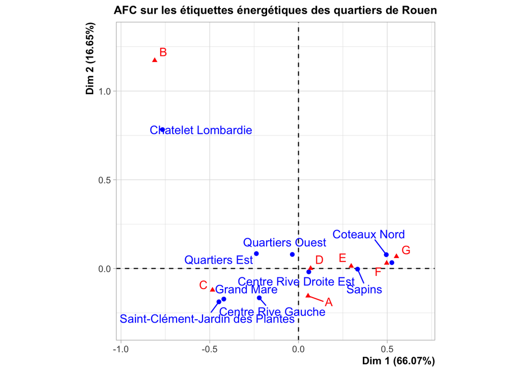

```r
afc <- CA(tabcont,graph = F)
plot.CA(afc,title = "AFC sur les étiquettes énergétiques des quartiers de Rouen")
```

Cette analyse met en valeur la situation très particulière dy quartier Chatelet-Lombardie qui est le seul à ne comprendre aucune passoire énergétique (F et G) et concentre un nombre exceptionnel de logements d’étiquette B. S’agit-il d’un biais de collecte ? ou d’une spécificité de ce quartier ?

### Classification ascendante hiérarchique

On réalise une CAH sur les axes de l’AFC pour téablir une typologie des quartiers.

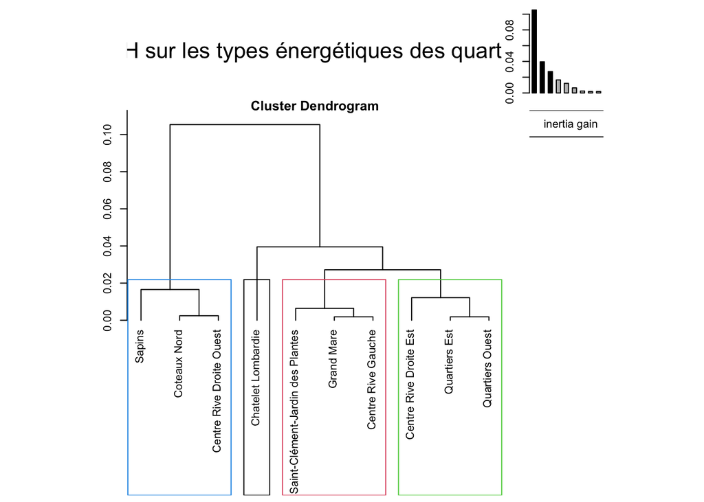

```r
cah <- HCPC(afc, nb.clust = 4,graph = F)
plot.HCPC(cah,choice = "tree",title = "CAH sur les types énergétiques des quartiers")
```